# Penguins and Birthdays

DEADLINE FOR COMPLETING THIS LAB: Friday, 3rd November  
GROUP WORK. One member of your group submits your final report [using this form](https://forms.gle/JB5c9apmkx3wD8WG7).

## Penguins

Between 2007 and 2009, researchers collected data on penguins in three islands in the Palmer Archipelago in Antarctica: Biscoe, Dream, and Torgersen. The `penguins` dataset has data for 342 penguins from 3 different species: Chinstrap, Gentoo, and Adélie. It includes the following variables:

- `species`: The penguin’s species (Chinstrap, Gentoo, and Adélie)
- `island`: The island where the penguin lives (Biscoe, Dream, and Torgersen)
- `bill_length_mm`: The length of the penguin’s bill, in millimeters (distance from the penguin’s face to the tip of the bill)
- `bill_depth_mm`: The depth of the penguin’s bill, in millimeters (height of the bill; distance from the bottom of the bill to the top of the bill)
- `flipper_length_mm`: The length of the penguin’s flippers, in millimeters
- `body_mass_g`: The weight of the penguin, in grams
- `sex`: The sex of the penguin
- `year`: The year the observation was made

### Creating a reproducible lab report

We will be using R Markdown to create reproducible lab reports. In RStudio, you will find the file `lab-04.Rmd` in the `Files` panel. Double click it to show the script in the code panel.

- In the file, update the YAML with your name, the date and the name of the lab.
- Load the `tidyverse`, `broom`, `table1` and `modelsummary` packages.
- Load the `penguins.rds` data set into your workspace, and save it as `penguins`. Notice that this time the file you are reading has an `rds` extension. You will therefore need to use the `read_rds` function to read it.
- knit your file to see that everything is working.

## Creating Table1

In most published articles, there is a “Table 1” containing descriptive statistics for the sample. This may include, for example, the mean and standard deviation for continuous variables, the frequency and proportion for categorical variables, and perhaps also the number of missing values.

The brute force method of creating such a table would be to compute each statistic for each variable of interest and then copy and paste the results into a table. Having done this even once you will wish for an easier method! There are many possible solutions, but one that is quick and easy to use the `table1` package described in the [following vignette](https://cran.r-project.org/web/packages/table1/vignettes/table1-examples.html)

## Association between variables

1. Use the `table1` package to replicate the table below. Use the examples provided in the [following vignette](https://cran.r-project.org/web/packages/table1/vignettes/table1-examples.html).

Measurements for three penguin species in the Palmer Archipelago

|  | Adelie (N=151) | Chinstrap (N=68) | Gentoo (N=123) |
| --- | --- | --- | --- |
| Sex |  |  |  |
| female | 73 (48.3%) | 34 (50.0%) | 58 (47.2%) |
| male | 73 (48.3%) | 34 (50.0%) | 61 (49.6%) |
| Missing | 5 (3.3%) | 0 (0%) | 4 (3.3%) |
| Body mass (g) |  |  |  |
| Mean (SD) | 3700 (459) | 3730 (384) | 5080 (504) |
| Median [Min, Max] | 3700 [2850, 4780] | 3700 [2700, 4800] | 5000 [3950, 6300] |
| Flipper length (mm) |  |  |  |
| Mean (SD) | 190 (6.54) | 196 (7.13) | 217 (6.48) |
| Median [Min, Max] | 190 [172, 210] | 196 [178, 212] | 216 [203, 231] |
| Bill depth (mm) |  |  |  |
| Mean (SD) | 18.3 (1.22) | 18.4 (1.14) | 15.0 (0.981) |
| Median [Min, Max] | 18.4 [15.5, 21.5] | 18.5 [16.4, 20.8] | 15.0 [13.1, 17.3] |
| island |  |  |  |
| Biscoe | 44 (29.1%) | 0 (0%) | 123 (100%) |
| Dream | 56 (37.1%) | 68 (100%) | 0 (0%) |
| Torgersen | 51 (33.8%) | 0 (0%) | 0 (0%) |

Notice that each point in the graph is associated with a penguin, and for each penguin we have information about its different features: weight, bill depth, flipper length etc.

2. Replicate the scatter plot below, coloring the points according to the species. What can you tell about the relationship between bill depth and penguin weight? Comment on the intercepts and the slopes, associated with the three species (are they the same? similar? different). Does the outcome variable appear normally distributed? Why is that important?

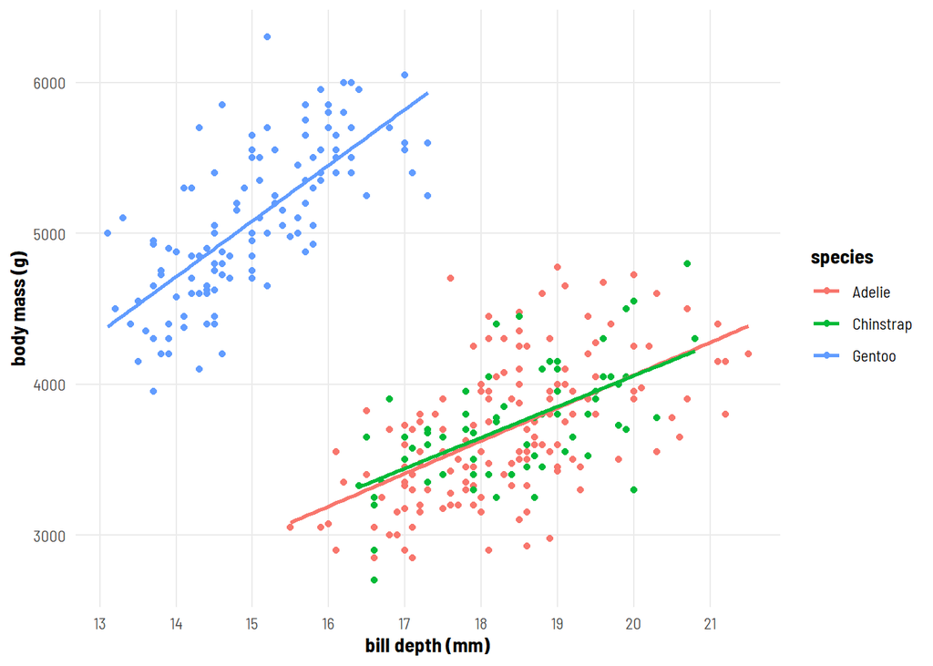

4. Now replicate the plot below, illustrating the relationship between flipper length and body mass, points colored by `species`. Facet the plot by island (if you forgot how to use it, just search it online). Finally, tell a story about the relationship between flipper length and weight in these three penguin species, and the distribution of penguins across the three islands.

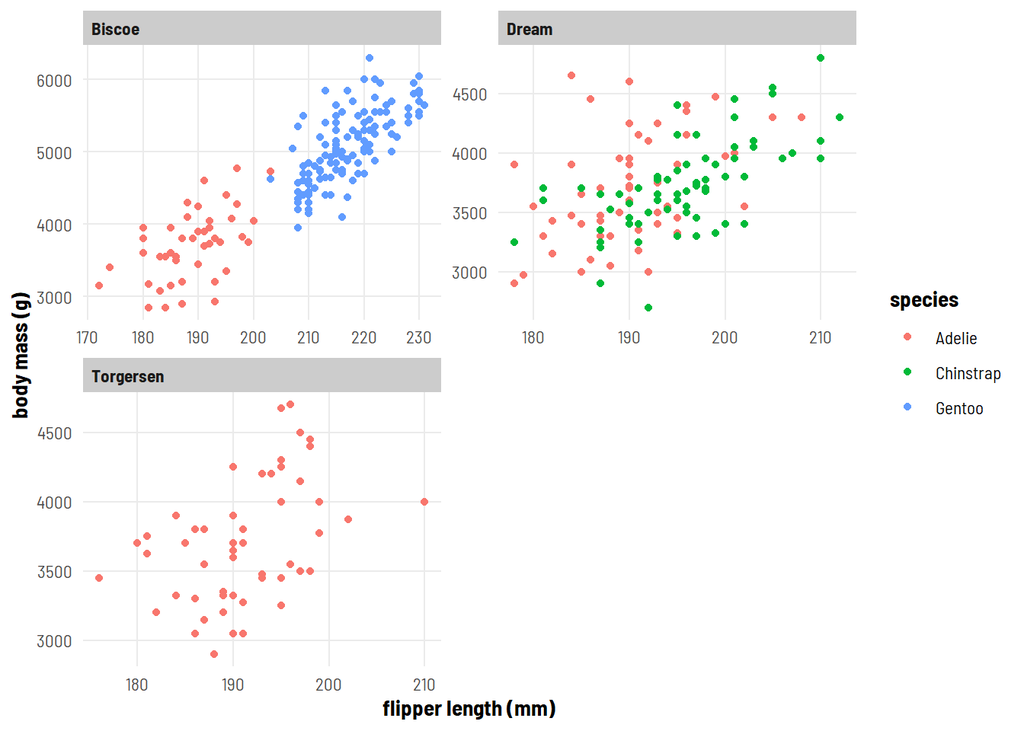

```r
ggplot(data = penguins,
       aes(x = _______, y = ________, color = ___________)) +
  geom___________ +
  facet_grid(island~.)
```

5. Replicate the scatter plot below, adding vertical and horizontal lines to indicate the mean of the predictor and of the outcome variable. Show that the linear regression line passes at the intersection of the two means.

To create the horizontal and vertical lines, please use the layers `geom_vline(xintercept = ___)` and `geom_hline(yintercept = = ___)`

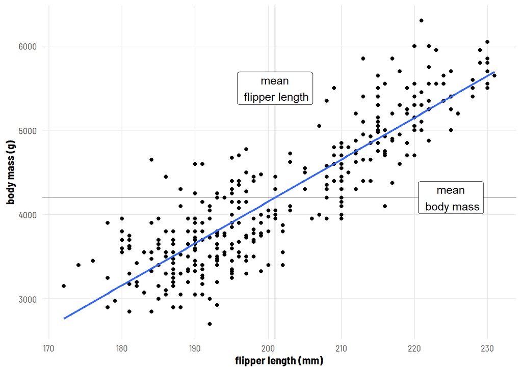

```r
M1 <- lm(body_mass_g ~ flipper_length_mm,
                         data = penguins)

summary(M1)
tidy(M1, conf.int = TRUE)
glance(M1)
```

> Linear regression was used to test the association between _____ (_____) and _____ (_____) using data from n = _____ Penguins. _____% of the variation in _____ was explained by _____ ($R^2 =$ _____). There was a significant _____ (positive/negative) association between _____ and _____ (B = _____; 95% CI = _____, _____; p < .001). On average, for every 1-mm difference in _____, penguins differ in mean _____ by _____ grams.